# Projet Jedha - Uber pick ups

#### Directives

Essayez de voir le nombre de clusters optimum

Trouver ces clusters sur une map

Séparez maintenant ces clusters en fonction des périodes de la journée

Regardez la différence KMeans et DBSCAN

```python
import numpy as np
import pandas as pd
import matplotlib.pyplot as plt
import seaborn as sns
import warnings
from datetime import datetime
warnings.filterwarnings('ignore')
```

```python
# Let's put the file names in a variable

from os import listdir

def find_csv_filenames( path_to_dir, suffix=".csv") :
    filenames = listdir(path_to_dir)
    return [ filename for filename in filenames if filename.endswith( suffix ) ]

file_names = find_csv_filenames("uber-trip-data")
file_names
```

```
['taxi-zone-lookup.csv',
 'uber-raw-data-apr14.csv',
 'uber-raw-data-aug14.csv',
 'uber-raw-data-janjune-15.csv',
 'uber-raw-data-jul14.csv',
 'uber-raw-data-jun14.csv',
 'uber-raw-data-may14.csv',
 'uber-raw-data-sep14.csv']
```

```python
dataset = pd.DataFrame()
for file in set(file_names) - {"taxi-zone-lookup.csv", "uber-raw-data-janjune-15.csv"}:
    dataset = dataset.append(pd.read_csv("uber-trip-data/"+file))

dataset.rename(columns={"Date/Time": "Date_time"}, inplace=True)

taxi_zone = pd.read_csv("uber-trip-data/taxi-zone-lookup.csv")

print("size dataset " ,len(dataset))
```

```
size dataset  4534327
```

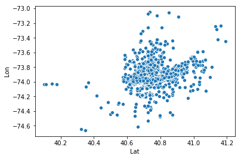

```python
sns.scatterplot("Lat", "Lon", data = sample_data)
```

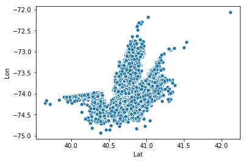

```python
sns.scatterplot("Lat", "Lon", data = dataset)
```

```python
# The dataset is quite large so we are going to take only a sample of it
sample_data = dataset.sample(n= 30000, random_state=42, axis = 0 )

# There are no data missing (no NaN) in our sample. We are going to create 3 columns Day/ Month / Time / Year

sample_data.Date_time = pd.to_datetime(sample_data.Date_time, infer_datetime_format=True)
sample_data["Month"] = sample_data.Date_time.apply(lambda x :x.month)
sample_data["Day"] = sample_data.Date_time.apply(lambda x : x.day)
sample_data["Hour"] = sample_data.Date_time.apply(lambda x : x.hour)

sample_data.drop(["Date_time","Base"],axis = 1, inplace = True)
```

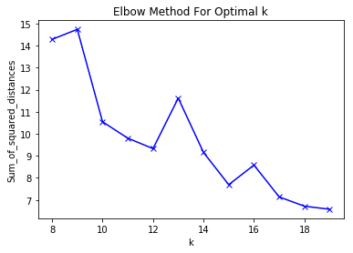

```python
# We are first going to try to find clusters with a centroid using the KMeans technic. Given that our dataset
# represent coordinates in a city (NY) we are going to use the manhattan distance.
# However this distance is not usable with Kmeans in sklearn. Let's first try a simple K-means with Euclidian distance

# First to familiarise with clustering we are going to create clusters based on Latitude and Longitude
sample_data1 = sample_data.drop(["Month","Day", "Hour"], axis =1)

# We start by normalising our variables with a MinMax scaler

from sklearn.preprocessing import MinMaxScaler
MinMaxS = MinMaxScaler()
sample_data1 = pd.DataFrame(MinMaxS.fit_transform(sample_data1), columns = sample_data1.columns)

# Then we use Kmeans. Let's say we want to divide the whole pick up zone in clusters and we'd like to figure out how manies
# To help us decide, let's do a elbow chart analysis
# To process the data faster we are using MiniBatchKmean which is an implementation of K means only slightly less precise
# but a lot faster, especially with large datasets

from sklearn.cluster import MiniBatchKMeans

Sum_of_squared_distances = []
K = range(8,20)
for k in K:
    km = MiniBatchKMeans(n_clusters=k, random_state = 42, )
    km = km.fit(sample_data1)
    Sum_of_squared_distances.append(km.inertia_)  # ici on peut utiliser .score au lieu d'inertia_

plt.plot(K, Sum_of_squared_distances, 'bx-')
plt.xlabel('k')
plt.ylabel('Sum_of_squared_distances')
plt.title('Elbow Method For Optimal k')
plt.show()
```

Conclusion : 12 clusters seems like a decent choice

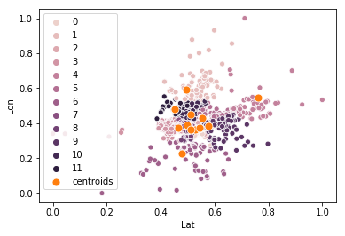

```python
from sklearn.cluster import KMeans
cluster_K = MiniBatchKMeans(n_clusters = 12, random_state =42 )

cluster_K.fit_transform(sample_data1)

# From there we can for get the latitude and longitude of the centroids which will be first, even though imperfect,
# approximation of where a uber driver wants to park to minimise the average distance to next pick-up (based on euclidian distance)

coords_centers = pd.DataFrame(cluster_K.cluster_centers_, columns = ["Lat","Lon"])
# And we can easily show the different clusters and where it should be better to park

sns.scatterplot("Lat", "Lon", data = sample_data1, hue =cluster_K.labels_, legend="full")
sns.scatterplot("Lat", "Lon", data = coords_centers, s=80, legend = "full", label = "centroids", )
plt.legend()
plt.show()
```

```python
# For the sake of the excercise, let's go further. We can now tell uber where their drivers should wait.
# Let's now tell uber how to spread their drivers
# If we assume uber want to spread them based on the number of pick ups :

for i in np.arange(0,12):
    dico[i] =0

for cle in df_labels[0] :
    dico[cle] += 1

for cle in dico:
    dico[cle] = int((dico[cle] /len(sample_data1))*1000)/10

(pd.DataFrame(dico, index=["frequency"])
 .transpose()
 .sort_values(by = "frequency",ascending = False)
)
```

|  | frequency |
| --- | --- |
| 8 | 32.2 |
| 2 | 26.5 |
| 0 | 19.1 |
| 11 | 6.6 |
| 1 | 5.9 |
| 5 | 3.5 |
| 4 | 2.6 |
| 3 | 1.6 |
| 6 | 0.9 |
| 7 | 0.2 |
| 10 | 0.2 |
| 9 | 0.0 |

And just like that we have an indication of the distribution of drivers by cluster. Forgetting that the technic used is fairly flawed, we could split each of these cluster in sub-cluster to distribute drivers and thus minimising distance to pick up and customers waiting time

Now let's add some dimensions in our clustering : Day and Hour of the day

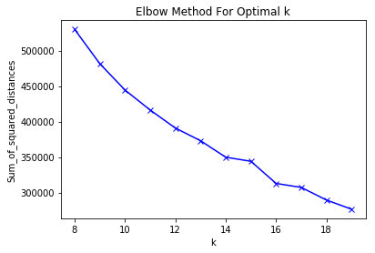

```python
# We are first going to try to find clusters with a centroid using the KMeans technic. Given that our dataset
# represent coordinates in a city (NY) we are going to use the manhattan distance.
# However this distance is not usable with Kmeans in sklearn. Let's first try a simple K-means with Euclidian distance

# First to familiarise with clustering we are going to create clusters based on Latitude and Longitude
sample_data2 = sample_data.drop(["Month","Day"], axis =1)

# We start by normalising our variables with a MinMax scaler

from sklearn.preprocessing import MinMaxScaler
MinMaxS = MinMaxScaler()
sample_data2 = pd.DataFrame(MinMaxS.fit_transform(sample_data2), columns = sample_data2.columns)

# Then we use Kmeans. Let's say we want to divide the whole pick up zone in clusters and we'd like to figure out how manies
# To help us decide, let's do a elbow chart analysis
# To process the data faster we are using MiniBatchKmean which is an implementation of K means only slightly less precise
# but a lot faster, especially with large datasets

from sklearn.cluster import MiniBatchKMeans

Sum_of_squared_distances = []
K = range(8,20)
for k in K:
    km = MiniBatchKMeans(n_clusters=k, random_state = 42, )
    km = km.fit(sample_data)
    Sum_of_squared_distances.append(km.inertia_)  # ici on peut utiliser .score au lieu d'inertia_

plt.plot(K, Sum_of_squared_distances, 'bx-')
plt.xlabel('k')
plt.ylabel('Sum_of_squared_distances')
plt.title('Elbow Method For Optimal k')
plt.show()
```

```python
sample_data2.head()
```

|  | Lat | Lon | Hour |
| --- | --- | --- | --- |
| 0 | 0.591417 | 0.393637 | 1.000000 |
| 1 | 0.551930 | 0.384778 | 0.913043 |
| 2 | 0.506976 | 0.352741 | 0.826087 |
| 3 | 0.548666 | 0.369735 | 0.695652 |
| 4 | 0.536183 | 0.367339 | 0.869565 |

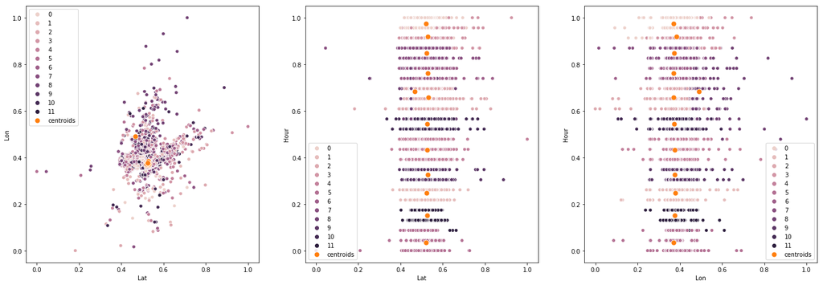

```python
# Looking at the elbow graph,let's try and keep 12 cluster for comparison purposes

from sklearn.cluster import KMeans
cluster_K = MiniBatchKMeans(n_clusters = 12, random_state =42 )

cluster_K.fit_transform(sample_data2)

# From there we can for get the latitude and longitude of the centroids which will be first, even though imperfect,
# approximation of where a uber driver wants to park to minimise the average distance to next pick-up (based on euclidian distance)

coords_centers = pd.DataFrame(cluster_K.cluster_centers_, columns = ["Lat","Lon","Hour"])
# And we can easily show the different clusters and where it should be better to park

f, ax = plt.subplots(1,3, figsize= (24,8))
sns.scatterplot("Lat", "Lon", data = sample_data2, hue =cluster_K.labels_, legend="full", ax = ax[0])
sns.scatterplot("Lat", "Lon", data = coords_centers, s=80, legend = "full", label = "centroids",ax = ax[0] )

sns.scatterplot("Lat", "Hour", data = sample_data2, hue =cluster_K.labels_, legend="full", ax = ax[1])
sns.scatterplot("Lat", "Hour", data = coords_centers, s=80, legend = "full", label = "centroids",ax = ax[1] )

sns.scatterplot("Lon", "Hour", data = sample_data2, hue =cluster_K.labels_, legend="full", ax = ax[2])
sns.scatterplot("Lon", "Hour", data = coords_centers, s=80, legend = "full", label = "centroids",ax = ax[2] )

plt.legend()
plt.show()
```

What this seems to tell us is that pick up are mostly distributed throughout the day rather than throughout long and lat. In other terms, assuming a finite number of drivers, uber would be better off having throughout the whole day rather than distributed all over Manhattan. Of course operationnally speaking this result is not satisfying and we would like to have geographical clusters for each period of the day. Assuming a base shift of 8 hour for a driver, let's divide the day in 3 periods.

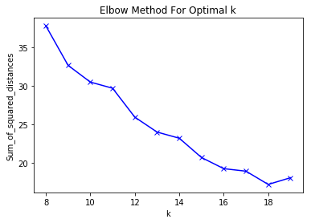

```python
# We are first going to try to find clusters with a centroid using the KMeans technic. Given that our dataset
# represent coordinates in a city (NY) we are going to use the manhattan distance.
# However this distance is not usable with Kmeans in sklearn. Let's first try a simple K-means with Euclidian distance

# First to familiarise with clustering we are going to create clusters based on Latitude and Longitude
sample_data3 = sample_data.drop(["Month","Day"], axis =1)

# We categorise Hour in 3 subcategories

sample_data3.Hour = sample_data3.Hour.apply(lambda x :
                                           0 if x < 8 else
                                           1 if x < 16 else
                                           2)

# We start by normalising our variables with a MinMax scaler



from sklearn.preprocessing import MinMaxScaler
MinMaxS = MinMaxScaler()
sample_data3 = pd.DataFrame(MinMaxS.fit_transform(sample_data3), columns = sample_data3.columns)

# Then we use Kmeans. Let's say we want to divide the whole pick up zone in clusters and we'd like to figure out how manies
# To help us decide, let's do a elbow chart analysis
# To process the data faster we are using MiniBatchKmean which is an implementation of K means only slightly less precise
# but a lot faster, especially with large datasets

from sklearn.cluster import MiniBatchKMeans

Sum_of_squared_distances = []
K = range(8,20)
for k in K:
    km = MiniBatchKMeans(n_clusters=k, random_state = 42, )
    km = km.fit(sample_data3)
    Sum_of_squared_distances.append(km.inertia_)  # ici on peut utiliser .score au lieu d'inertia_

plt.plot(K, Sum_of_squared_distances, 'bx-')
plt.xlabel('k')
plt.ylabel('Sum_of_squared_distances')
plt.title('Elbow Method For Optimal k')
plt.show()
```

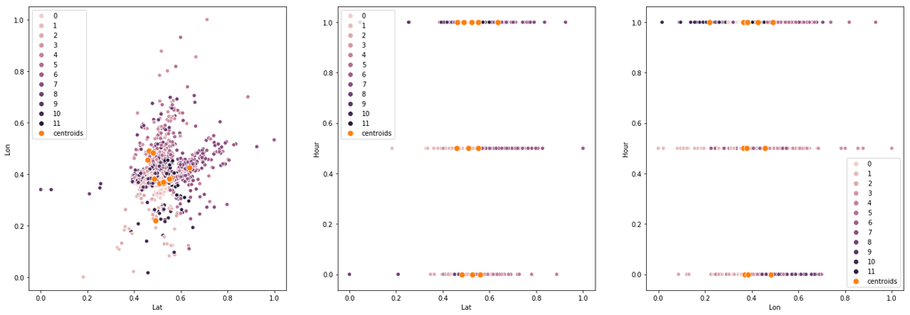

```python
# Looking at the elbow graph,let's try and keep 12 cluster for comparison purposes

from sklearn.cluster import KMeans
cluster_K = MiniBatchKMeans(n_clusters = 12, random_state =42 )

cluster_K.fit_transform(sample_data3)

# From there we can for get the latitude and longitude of the centroids which will be first, even though imperfect,
# approximation of where a uber driver wants to park to minimise the average distance to next pick-up (based on euclidian distance)

coords_centers = pd.DataFrame(cluster_K.cluster_centers_, columns = ["Lat","Lon","Hour"])
# And we can easily show the different clusters and where it should be better to park

f, ax = plt.subplots(1,3, figsize= (24,8))
sns.scatterplot("Lat", "Lon", data = sample_data3, hue =cluster_K.labels_, legend="full", ax = ax[0])
sns.scatterplot("Lat", "Lon", data = coords_centers, s=80, legend = "full", label = "centroids",ax = ax[0] )

sns.scatterplot("Lat", "Hour", data = sample_data3, hue =cluster_K.labels_, legend="full", ax = ax[1])
sns.scatterplot("Lat", "Hour", data = coords_centers, s=80, legend = "full", label = "centroids",ax = ax[1] )

sns.scatterplot("Lon", "Hour", data = sample_data3, hue =cluster_K.labels_, legend="full", ax = ax[2])
sns.scatterplot("Lon", "Hour", data = coords_centers, s=80, legend = "full", label = "centroids",ax = ax[2] )

plt.legend()
plt.show()
```

```python
coords_centers
```

[output not shown]

Now let's have a go at using DBscan. This is a bit more challenging as we need to give a "distance" parameter between two points and a minimum number of points we want within this distance to another point of the dataset.

```python
# Let's have a look at the maximum distance between two points far away to get an idea of the scale
# manhattan distance is computed as

max_dist_dataset = abs(sample_data.Lat.min()-sample_data.Lat.max() + sample_data.Lon.min()-sample_data.Lon.max())
mean_dist_dataset = abs(sample_data.Lat.mean()-sample_data.Lat.max() + sample_data.Lon.mean()-sample_data.Lon.max())
max_dist_dataset
mean_dist_dataset
```

```
0.9793339733243063
```

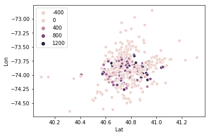

```python
from sklearn.cluster import DBSCAN
DB_cluster = DBSCAN(eps=0.3,
                    min_samples=10, metric="manhattan")
DB_cluster.fit(sample_data)
DB_cluster.labels_
sns.scatterplot("Lat", "Lon", data = sample_data, hue = DB_cluster.labels_)
```

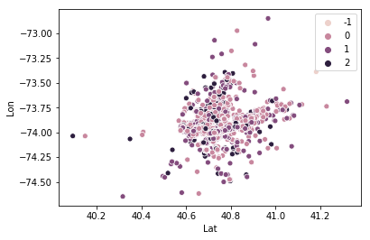

```python
from sklearn.cluster import DBSCAN
DB_cluster = DBSCAN(eps=0.3,
                    min_samples=10, metric="manhattan")
DB_cluster.fit(sample_data3)
DB_cluster.labels_
sns.scatterplot("Lat", "Lon", data = sample_data, hue = DB_cluster.labels_)
```

It looks pretty difficult to get anything out of DB scan